# Part I - Loan Data from Prosper

## Introduction

The dataset contain information on 113,937 loans with each loan having 81 variables, including loan amount, borrower/interest rate, current loan status, borrower income and others. The goal of this analysis is to assess the possible reasons for not completing loan repayment

## Preliminary Wrangling

```python
# import all packages and set plots to be embedded inline
import numpy as np
import pandas as pd
import matplotlib.pyplot as plt
import seaborn as sb

%matplotlib inline
```

> Load in your dataset and describe its properties through the questions below. Try and motivate your exploration goals through this section.

```python
#load dataset
loan = pd.read_csv("C:/Users/msami/Desktop/prosperLoanData.csv")
```

```python
#get more information on dataset
print(loan.shape)
loan.info()
```

```
(113937, 81)
<class 'pandas.core.frame.DataFrame'>
RangeIndex: 113937 entries, 0 to 113936
Data columns (total 81 columns):
 #   Column                               Non-Null Count   Dtype
---  ------                               --------------   -----
 0   ListingKey                           113937 non-null  object
 1   ListingNumber                        113937 non-null  int64
 2   ListingCreationDate                  113937 non-null  object
 3   CreditGrade                          28953 non-null   object
 4   Term                                 113937 non-null  int64
 5   LoanStatus                           113937 non-null  object
 6   ClosedDate                           55089 non-null   object
 7   BorrowerAPR                          113912 non-null  float64
 8   BorrowerRate                         113937 non-null  float64
```

[output cut: 74 more lines]

#### Wrangling

> Not all the 81 feature are relevant to our analysis, it is important to keep the selection in moderation so as to avoid being lost in the noise

```python
cols = ["ListingKey", "Term", "LoanStatus", "BorrowerAPR", "BorrowerRate", "ProsperScore",
        "ListingCategory (numeric)","BorrowerState", "Occupation", "EmploymentStatus",
        "EmploymentStatusDuration", "IncomeRange", "StatedMonthlyIncome", "IsBorrowerHomeowner",
        "LoanOriginalAmount", "MonthlyLoanPayment", "Recommendations"]
```

```python
df =  loan[cols]
```

```python
# gain insight the loan status
df["LoanStatus"].value_counts()
```

```
Current                   56576
Completed                 38074
Chargedoff                11992
Defaulted                  5018
Past Due (1-15 days)        806
Past Due (31-60 days)       363
Past Due (61-90 days)       313
Past Due (91-120 days)      304
Past Due (16-30 days)       265
FinalPaymentInProgress      205
Past Due (>120 days)         16
Cancelled                     5
Name: LoanStatus, dtype: int64
```

We are going to drop all current loans and categorize all other loans other than "completed" as "defaulted"

```python
df = df[df["LoanStatus"] != "Current"]
```

```python
# all completed loans will be represented by the integer 1 while 0 for the rest
df["LoanStatus"] = (df["LoanStatus"] == "Completed").astype(int)
```

```python
#confirm whethter the changes are implemented
df["LoanStatus"].value_counts()
```

```
1    38074
0    19287
Name: LoanStatus, dtype: int64
```

```python
df.describe()
```

|  | Term | LoanStatus | BorrowerAPR | BorrowerRate | ProsperScore | ListingCategory (numeric) | EmploymentStatusDuration | StatedMonthlyIncome | LoanOriginalAmount | MonthlyLoanPayment | Recommendations |
| --- | --- | --- | --- | --- | --- | --- | --- | --- | --- | --- | --- |
| count | 57361.000000 | 57361.000000 | 57336.000000 | 57361.000000 | 28277.000000 | 57361.000000 | 49746.000000 | 57361.000000 | 57361.000000 | 57361.000000 | 57361.00000 |
| mean | 37.199142 | 0.663761 | 0.223848 | 0.201634 | 6.174382 | 2.468663 | 81.616592 | 5070.249904 | 6340.889193 | 225.871821 | 0.08633 |
| std | 7.649302 | 0.472426 | 0.087895 | 0.080952 | 2.330209 | 3.484849 | 85.133652 | 5644.529440 | 5248.411068 | 185.718573 | 0.44570 |
| min | 12.000000 | 0.000000 | 0.006530 | 0.000000 | 1.000000 | 0.000000 | 0.000000 | 0.000000 | 1000.000000 | 0.000000 | 0.00000 |
| 25% | 36.000000 | 0.000000 | 0.152110 | 0.136400 | 4.000000 | 0.000000 | 21.000000 | 2833.333333 | 2800.000000 | 100.710000 | 0.00000 |
| 50% | 36.000000 | 1.000000 | 0.217390 | 0.198000 | 6.000000 | 1.000000 | 53.000000 | 4166.666667 | 4500.000000 | 173.690000 | 0.00000 |
| 75% | 36.000000 | 1.000000 | 0.295540 | 0.269900 | 8.000000 | 3.000000 | 113.000000 | 6250.000000 | 8000.000000 | 303.580000 | 0.00000 |
| max | 60.000000 | 1.000000 | 0.512290 | 0.497500 | 11.000000 | 20.000000 | 755.000000 | 618547.833333 | 35000.000000 | 2251.510000 | 39.00000 |

###### There seem to be quite a lot of outliers, hence we will drop any value below the 10th quantile and above the 90th quantile

```python
q1,q9 = df["StatedMonthlyIncome"].quantile([0.1, 0.9])
mask = df["StatedMonthlyIncome"].between(q1,q9)
df = df[mask]
```

```python
df["StatedMonthlyIncome"].describe()
```

```
count    45929.000000
mean      4517.327282
std       1763.945306
min       1824.000000
25%       3083.333333
50%       4166.666667
75%       5814.000000
max       8833.333333
Name: StatedMonthlyIncome, dtype: float64
```

```python
df.shape
```

```
(45929, 17)
```

### What is the structure of your dataset?

> 45929,17

### What is/are the main feature(s) of interest in your dataset?

> I am interest in the general characteristics of the borrowers as well as the factors that might affect loan completion amongst them.

### What features in the dataset do you think will help support your investigation into your feature(s) of interest?

> I expect to gain information from the occupation, monthly income, APR, Interest rate, recommentation, state, listing category and loan term

## Univariate Exploration

###### What is the most frequent loan term?

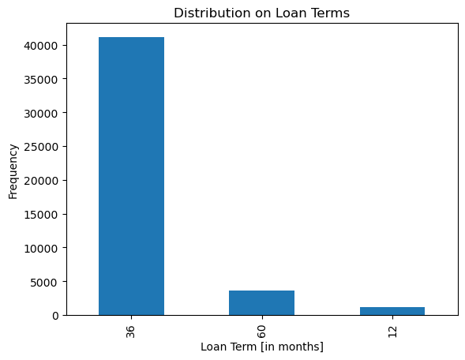

```python
df["Term"].value_counts().plot(kind="bar")
plt.xlabel("Loan Term [in months]")
plt.ylabel("Frequency")
plt.title("Distribution on Loan Terms")
```

> Most of the loans collected has a term length of 36 months

###### What proportion of the loans were completed before the due date?

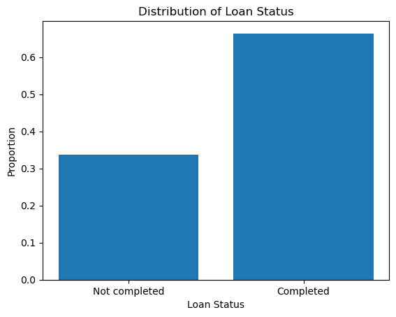

```python
x=df["LoanStatus"].unique()
y=df["LoanStatus"].value_counts(normalize=True)
plt.bar(x, y)
plt.xticks([0,1], ["Not completed", "Completed"])
plt.xlabel("Loan Status")
plt.ylabel("Proportion")
plt.title("Distribution of Loan Status");
```

> Majority of the loans are completed(>60%)

###### What is the distribution on home owners in the dataset?

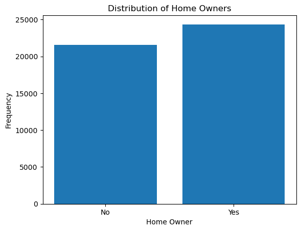

```python
x = df["IsBorrowerHomeowner"].unique()
y = df["IsBorrowerHomeowner"].value_counts()
plt.bar(x,y)
plt.xticks([0,1], ["No", "Yes"])
plt.xlabel("Home Owner")
plt.ylabel("Frequency")
plt.title("Distribution of Home Owners");
```

> The dataset contains more home owners.

###### What is the distribution of income amongst the borrowers?

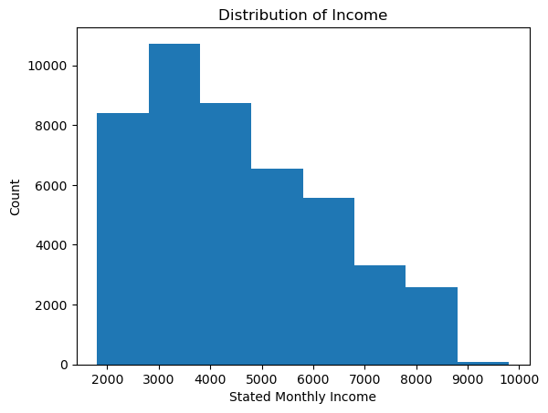

```python
#plot the income distribution
bins = np.arange(1800, 8900+1000, 1000)
plt.hist(data=df, x="StatedMonthlyIncome", bins=bins)
plt.xlabel("Stated Monthly Income")
plt.ylabel("Count")
plt.title("Distribution of Income")
```

###### What is the distribution of the loan amount

```python
df["LoanOriginalAmount"].describe()
```

```
count    45929.000000
mean      6120.846807
std       4879.369077
min       1000.000000
25%       2900.000000
50%       4500.000000
75%       8000.000000
max      35000.000000
Name: LoanOriginalAmount, dtype: float64
```

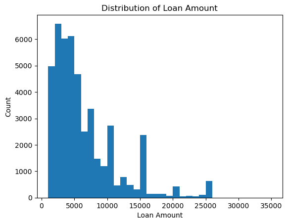

```python
#Create plot
bins = np.arange(1000, 35000+1000, 1000)
plt.hist(data=df, x="LoanOriginalAmount", bins=bins)
plt.xlabel("Loan Amount")
plt.ylabel("Count")
plt.title("Distribution of Loan Amount")
```

> The distribution of the loan amount is skewed to the right. The most frequent loan amounts are below 5000

###### What are the commonest reasons for loans?

```python
df["ListingCategory (numeric)"].unique()
```

```
array([ 0,  1, 13, 15, 20,  7, 19,  6, 18,  3,  4,  2, 16, 11,  5, 14, 10,
        9, 17,  8, 12], dtype=int64)
```

from the above, the loan categories are listed as numbers, we will try to make it more understandable

```python
#Create a dictionary with each number corresponding to the reason
listing_cat = {0:"Not Available", 1:"Debt Consolidation", 2:"Home Improvement", 3:"Business", 4:"Personal Loans",
          5:"Student Use", 6:"Auto", 7:"Other", 8:"Baby and Adoption", 9:"Boat", 10:"Cosmetic Procedure",
          11:"Engagement Ring", 12:"Green Loans", 13:"Household Expenses", 14:"Large Purchases", 15:"Medical/Dental",
          16:"Motorcycle", 17:"RV", 18:"Taxes", 19:"Vacation", 20:"Wedding Loans"}
```

```python
# make a function to change the numbers to the corresponding reason
def listing(loan):
    if loan["ListingCategory (numeric)"] in listing_cat.keys():
        category = listing_cat[loan["ListingCategory (numeric)"]]
        return category
    else:
        return loan["ListingCategory (numeric)"]
```

```python
#apply the function
df["ListingCategory (numeric)"] = df.apply(listing, axis=1)
```

```python
df["ListingCategory (numeric)"].unique()
```

```
array(['Not Available', 'Debt Consolidation', 'Household Expenses',
       'Medical/Dental', 'Wedding Loans', 'Other', 'Vacation', 'Auto',
       'Taxes', 'Business', 'Personal Loans', 'Home Improvement',
       'Motorcycle', 'Engagement Ring', 'Student Use', 'Large Purchases',
       'Cosmetic Procedure', 'Boat', 'RV', 'Baby and Adoption',
       'Green Loans'], dtype=object)
```

```python
#rename to column to a more fitting name
df.rename(columns={"ListingCategory (numeric)":"ListingCategory"}, inplace=True)
```

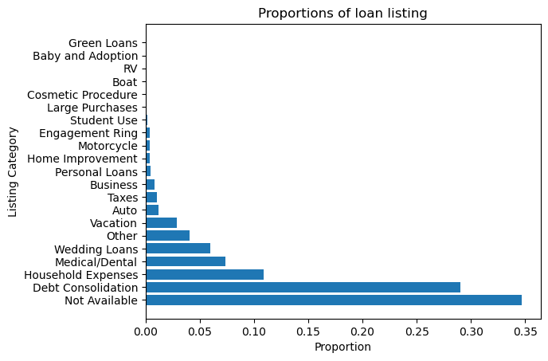

```python
x=df["ListingCategory"].unique()
y=df["ListingCategory"].value_counts(normalize=True)
plt.barh(x,y)
plt.xlabel("Proportion")
plt.ylabel("Listing Category")
plt.title("Proportions of loan listing")
```

###### What is the distribution of Borrower's Annual Percentage Rate?

```python
df["BorrowerAPR"].describe()
```

```
count    45917.000000
mean         0.225354
std          0.087389
min          0.006530
25%          0.154280
50%          0.220850
75%          0.295880
max          0.512290
Name: BorrowerAPR, dtype: float64
```

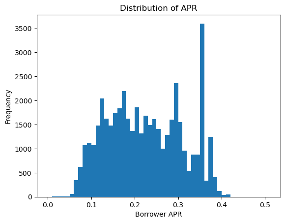

```python
bins = np.arange(0.0, 0.51+0.01, 0.01)
plt.hist(data=df, x="BorrowerAPR", bins=bins)
plt.xlabel("Borrower APR")
plt.ylabel("Frequency")
plt.title("Distribution of APR");
```

> The Commonest APR seems to around 0.35

###### What is the distribution of Borrower's Interest Rate?

```python
df["BorrowerRate"].describe()
```

```
count    45929.000000
mean         0.202992
std          0.080539
min          0.000000
25%          0.139000
50%          0.199400
75%          0.269900
max          0.497500
Name: BorrowerRate, dtype: float64
```

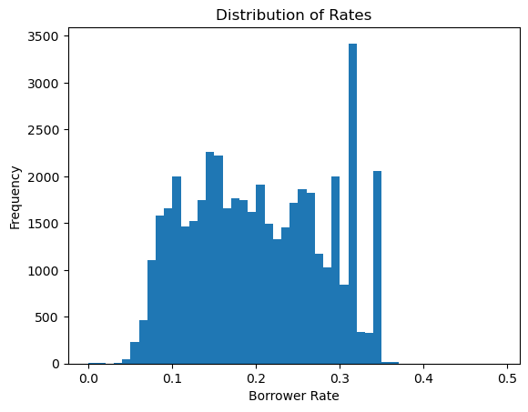

```python
bins = np.arange(0, 0.49+0.01, 0.01)
plt.hist(data=df, x="BorrowerRate", bins=bins)
plt.xlabel("Borrower Rate")
plt.ylabel("Frequency")
plt.title("Distribution of Rates");
```

> The commonest rate amongst borrowers is little above 0.3

### Discuss the distribution(s) of your variable(s) of interest. Were there any unusual points? Did you need to perform any transformations?

> Most of the loans were at 36 month loan term. More than 60% of the loans are completed. Majority of the borrowers are home owners. The loan amount is skewed to the right. The listing categories were in numbers, i converted them to their appropriate names for ease of understanding.

### Of the features you investigated, were there any unusual distributions? Did you perform any operations on the data to tidy, adjust, or change the form of the data? If so, why did you do this?

> The APR and interest rates seem to have a similar distribution.

## Bivariate Exploration

###### Is there any relationship between occupation and loan amount?

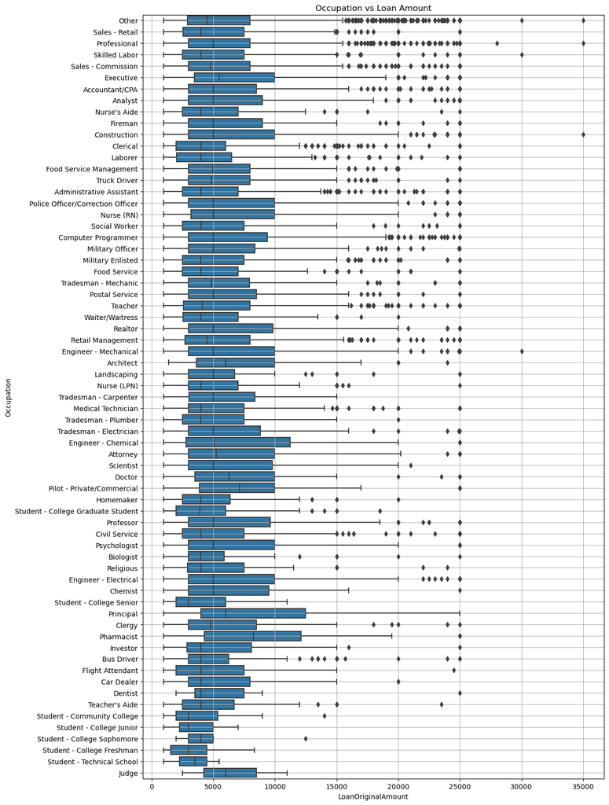

```python
# make a boxplot of the occupations against the loan amounts
plt.figure(figsize=[12, 20])
base_color = sb.color_palette()[0]
sb.boxplot(data=df, y="Occupation", x="LoanOriginalAmount", color=base_color)
plt.grid(True)
plt.title("Occupation vs Loan Amount");
```

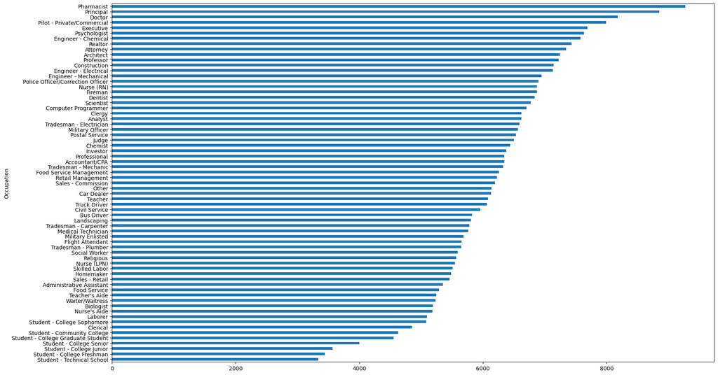

```python
#create a bar plot showing the average laon amounts per occupation
plt.figure(figsize=[20,12])
(df.groupby("Occupation")["LoanOriginalAmount"].mean().sort_values()).plot(kind="barh")
```

> The specialized occupations like pharmacists, doctors, pilots tend to have a highest loan amount on the average, while students are likely to take lower loans

###### Is there a relationship between the listing category and loan amounts?

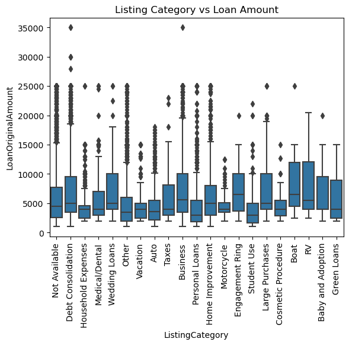

```python
sb.boxplot(data=df, x="ListingCategory", y="LoanOriginalAmount", color=base_color);
plt.xticks(rotation=90)
plt.title("Listing Category vs Loan Amount");
```

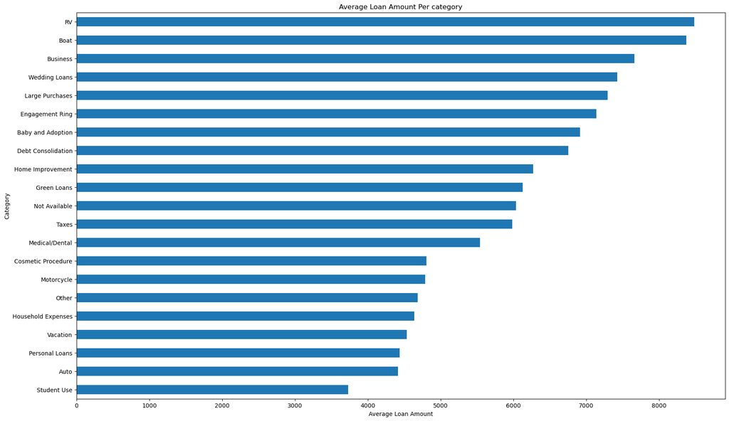

```python
#create a bar plot showing the average laon amounts per category
plt.figure(figsize=[20,12])
(df.groupby("ListingCategory")["LoanOriginalAmount"].mean().sort_values()).plot(kind="barh")
plt.xlabel("Average Loan Amount")
plt.ylabel("Category")
plt.title("Average Loan Amount Per category")
```

> The category with the highest average amount borrowed is the for "Recreational Vehicle (RV)" while "student use" has the lowest.

###### Is the any relationship between the monthly income and loan amount?

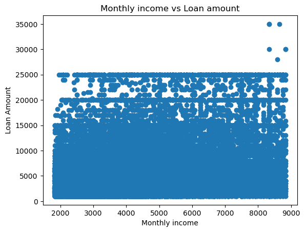

```python
plt.scatter(data=df, x="StatedMonthlyIncome", y="LoanOriginalAmount")
plt.xlabel("Monthly income")
plt.ylabel("Loan Amount")
plt.title("Monthly income vs Loan amount");
```

> The does not seem to be any relationship between income and loan amount.

###### Is there any relationship between occupation and income?

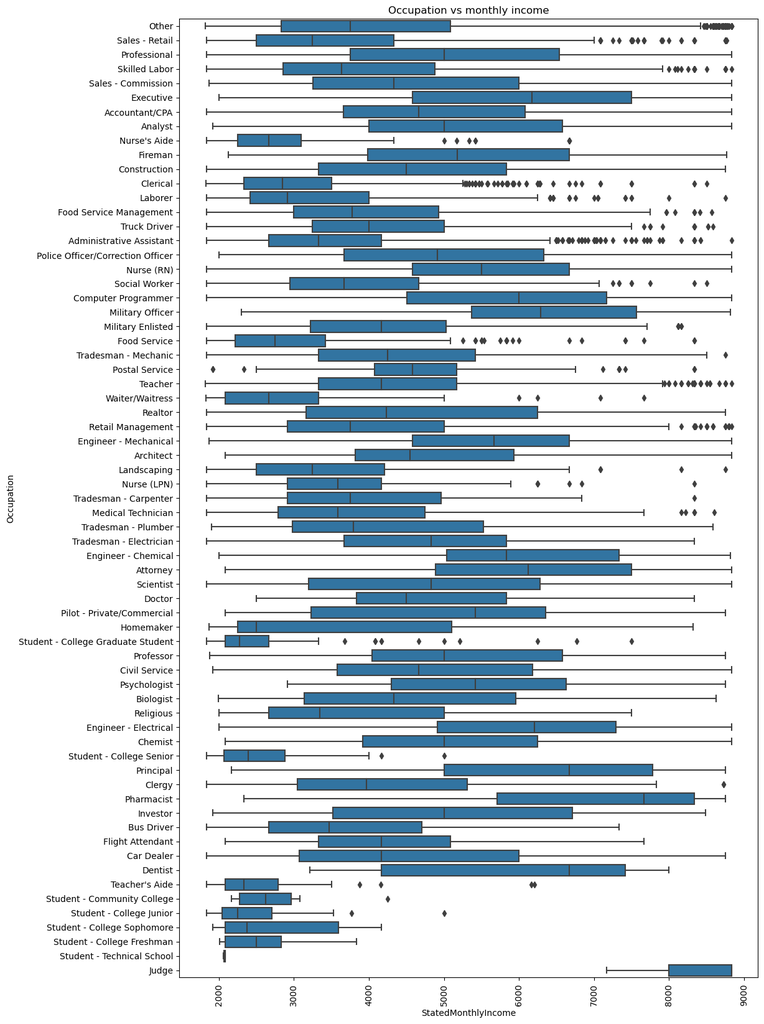

```python
# create a boxplot to check spread of income per occupation
plt.figure(figsize=[12,20])
sb.boxplot(data=df, y="Occupation", x="StatedMonthlyIncome", color=base_color)
plt.xticks(rotation=90)
plt.title("Occupation vs monthly income");
```

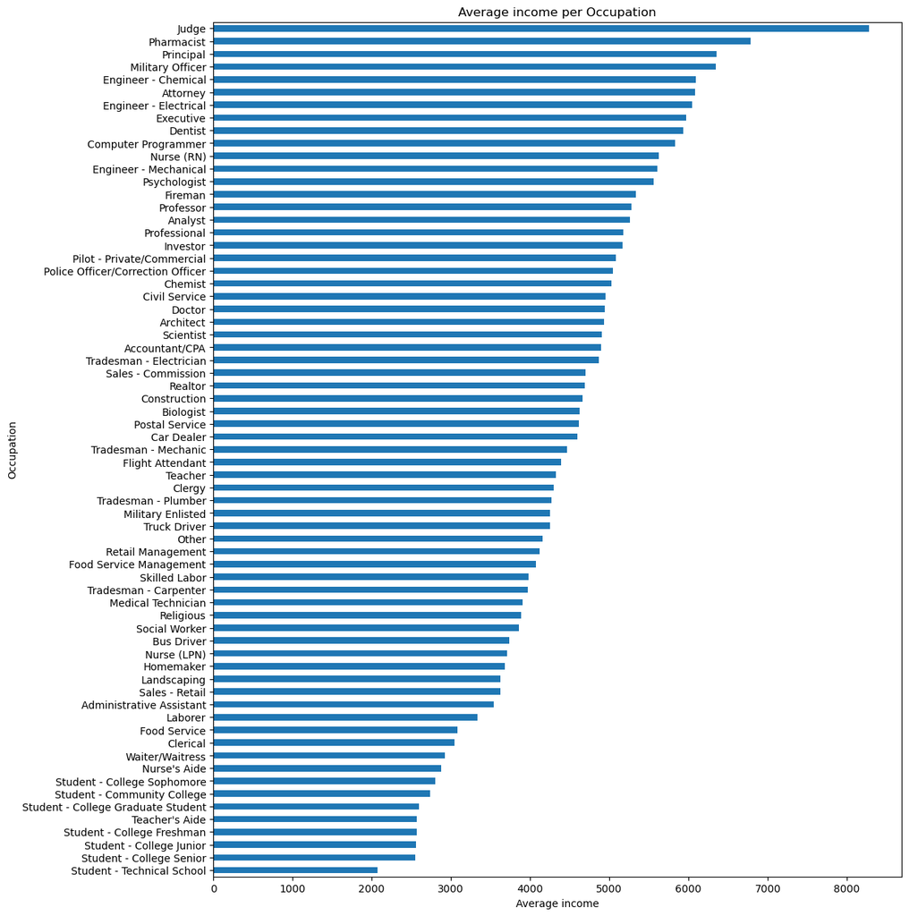

```python
plt.figure(figsize=[12,15])
(df.groupby("Occupation")["StatedMonthlyIncome"].mean().sort_values()).plot(kind="barh")
plt.xlabel("Average income")
plt.title("Average income per Occupation")
```

> Judges are the highest income earners on the average, while students earn the least

###### does higher income affect the chances of completing the loan payment?

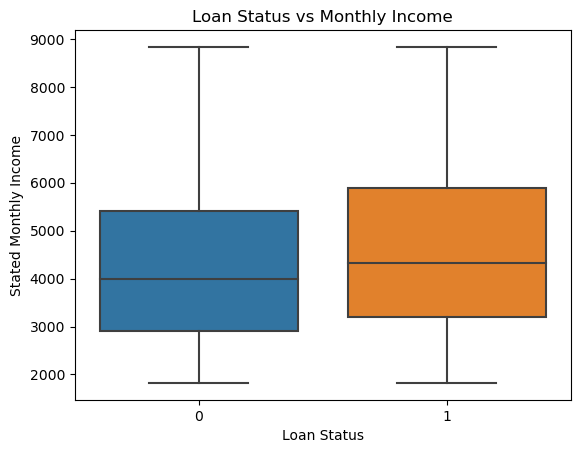

```python
# create a boxplot for the loan status against income
sb.boxplot(data=df, x="LoanStatus", y="StatedMonthlyIncome")
plt.xlabel("Loan Status")
plt.ylabel("Stated Monthly Income")
plt.title("Loan Status vs Monthly Income")
```

> Completed loans covered higher income borrowers.

###### What state has the highest loan completion rate?

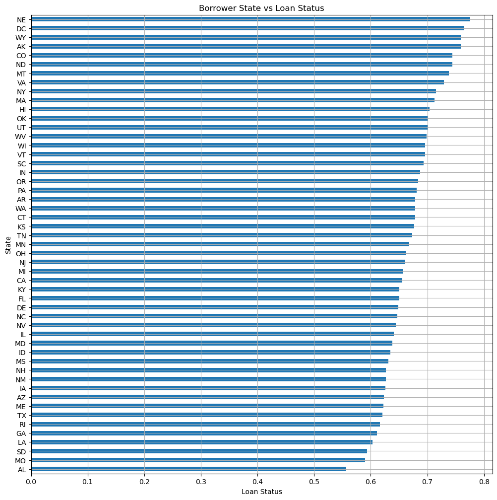

```python
plt.figure(figsize=[12,12])
(df.groupby("BorrowerState")["LoanStatus"].mean().sort_values()).plot(kind="barh")
plt.grid(True)
plt.xlabel("Loan Status")
plt.ylabel("State")
plt.title("Borrower State vs Loan Status");
```

> Borrowers from Nebraska tend to have a higher loan completion rate.

###### Does number of recommendation affect loan completion?

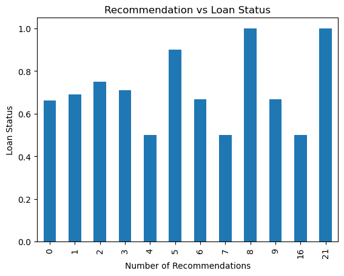

```python
#group the recommendations by loan status, then make a barchart
(df.groupby(["Recommendations"])["LoanStatus"].mean()).plot(kind="bar")
plt.xlabel("Number of Recommendations")
plt.ylabel("Loan Status")
plt.title("Recommendation vs Loan Status");
```

> the chart above shows, while a high number of recommendations (21) have a 100% completion rate, little or no recommention does not affect the completion rate.

###### Which occupation have a higher loan completion rate?

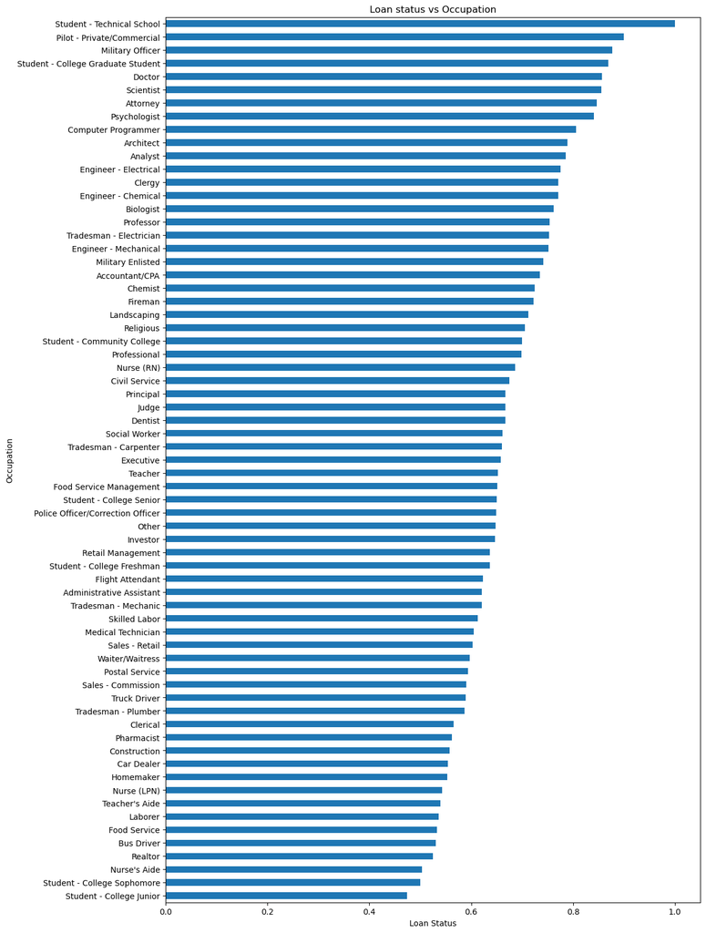

```python
plt.figure(figsize=[12,20])
(df.groupby(["Occupation"])["LoanStatus"].mean()).sort_values().plot(kind="barh")
plt.xlabel("Loan Status")
plt.ylabel("Occupation")
plt.title("Loan status vs Occupation");
```

###### Does the term of the loan affect its completion?

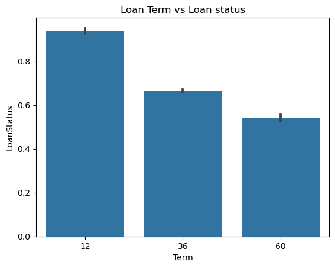

```python
sb.barplot(x="Term", y="LoanStatus", data=df, color=base_color)
plt.title("Loan Term vs Loan status");
```

> The lower the term, the higher the loan completion rate.

###### Does employment status affect the completion of loan?

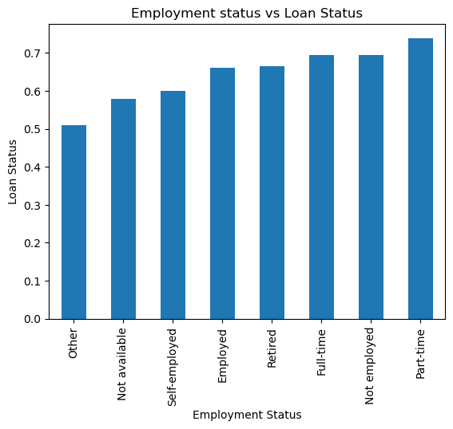

```python
(df.groupby(["EmploymentStatus"])["LoanStatus"].mean()).sort_values().plot(kind="bar")
plt.xlabel("Employment Status")
plt.ylabel("Loan Status")
plt.title("Employment status vs Loan Status");
```

> Part time workers tend to have a higher completion rate.

###### is there a relationship between monthly payment and loan amount?

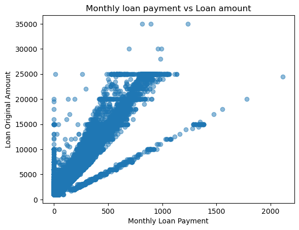

```python
plt.scatter(data=df, x="MonthlyLoanPayment", y="LoanOriginalAmount", alpha=0.5)
plt.xlabel("Monthly Loan Payment")
plt.ylabel("Loan Original Amount")
plt.title("Monthly loan payment vs Loan amount");
```

> the higher the loan amount, the higher the monthly payment.

###### Is there any relationship between Prosper Scores and the loan status?

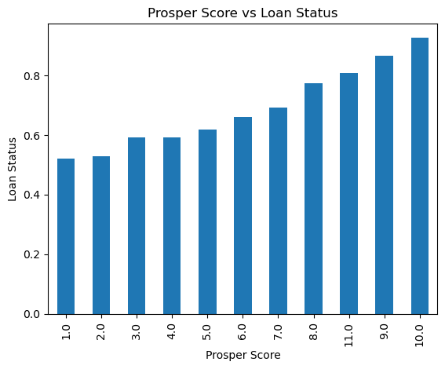

```python
#plot the Prosper score against loan status
(df.groupby("ProsperScore")["LoanStatus"].mean()).sort_values().plot(kind="bar")
plt.xlabel("Prosper Score")
plt.ylabel("Loan Status")
plt.title("Prosper Score vs Loan Status")
```

> Loan with higher prosper score tend to have a higher completion rate.

### Talk about some of the relationships you observed in this part of the investigation. How did the feature(s) of interest vary with other features in the dataset?

> Students had the least income and took the least amount of loans on average. Student use has least amount of loan borrowed. Borrowers from Nebraska had a higher loan completion rate, likewise, loan term of 12 months tend to be completed more often than others.

### Did you observe any interesting relationships between the other features (not the main feature(s) of interest)?

> I noted that the higher the loan amount, the higher the monthly payment rate.

## Multivariate Exploration

> Create plots of three or more variables to investigate your data even further. Make sure that your investigations are justified, and follow from your work in the previous sections.

###### what is the relationship between loan amount, interest rate and loan completion?

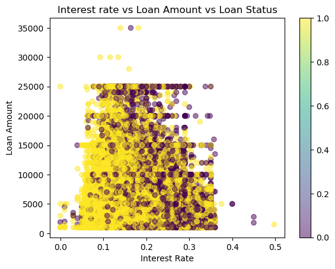

```python
plt.scatter(data=df, x="BorrowerRate", y="LoanOriginalAmount", c="LoanStatus", alpha=0.5)
plt.colorbar()
plt.ylabel("Loan Amount")
plt.xlabel("Interest Rate")
plt.title("Interest rate vs Loan Amount vs Loan Status")
```

###### what is the relationship between loan amount, Annual Percentage Rate and loan completion?

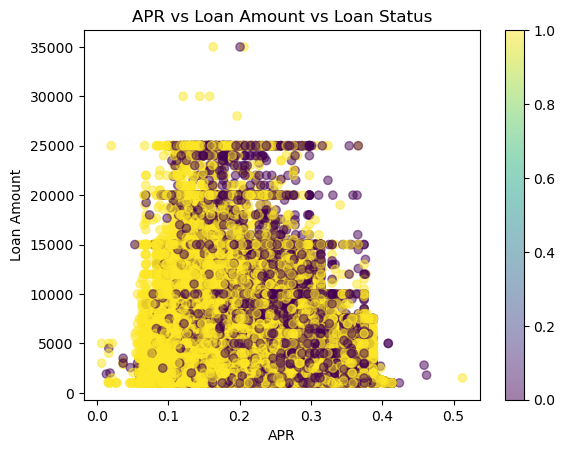

```python
plt.scatter(data=df, x="BorrowerAPR", y="LoanOriginalAmount", c="LoanStatus", alpha=0.5)
plt.colorbar()
plt.ylabel("Loan Amount")
plt.xlabel("APR")
plt.title("APR vs Loan Amount vs Loan Status")
```

> Higher Loan Amounts and APR tend to lead to decreased completion rates

### Talk about some of the relationships you observed in this part of the investigation. Were there features that strengthened each other in terms of looking at your feature(s) of interest?

> I noted that loan with higher amounts and/or APR tend to have a lower loan completion rate, same applies tp the interest rate.

### Were there any interesting or surprising interactions between features?

> Increasing the rate and APR could lead to reduction in loan completion.